# reading.in.data.R

joannarong

Wed Jun 22 16:10:36 2016

Turn list of co/chronic mobidity and mental health into “ture” and “false”

@param x the levels for patients in the original data frame to be turned into “ture” and “false” @param possible numbers of possible levels for co/chronic mobidity and mental health @return vectors of “ture” and “false” according to the levels of co/chronic mobidity and mental health

```r
extractmorbidity=function(x,possible) #possible=#of possible values for 16 or 23 values for chronic / co-mobidity
{
  if(x[1]==999||is.na(x[1]))
  {
    return(rep(F,possible))
  }else{
    has=rep(F,possible)
    for(i in x){
      has[i]=T
    }
    return(has)
  }
}

hasrepeat=function(x,possible)
{
  tab=table(x)
  m=max(tab)
  w=names(which.max(tab))
  ifelse(m>1,w,NA)
}

hasrepeat2=function(x,possible)
{
  tab=table(x)
  names(tab[tab>1])
}

#made fuction that label the specific values of each co-mobidity
extractco=function(x)
{
  thenames=c("Other","Eat","Hypert","Cardio","Kidney","Retino","Wounds","Neuro","Liver",
             "Vascular","Obesity","Cancer","Lipidd",
             "Thyroid","Dementia","Pulmon","sleep",
             "HIV","Pancreas","Celiac","Genetic","Deafblind","Mental")
  M=extractmorbidity(x,23)
  names(M)=thenames
  return(M)

}


#made functionthat label the specific values for each chronic-morbidity
extractchronic=function(x)
{
  thenames=c("COther","CNeuro","CRetino","CBlind","CCardio","CWounds",
             "Amput","Skin","Lipo","Hypo",
             "Diabetic","Foot","Stiff","Hear","Frac","Nephro")
  M=extractmorbidity(x,16)
  names(M)=thenames
  return(M)
}

extractMH=function(x)
{
  thenames=c("depress","OCD","schizophrenia","alcoholism","bipolar","anxiety","develop","delusional",
             "psychosis","mood","drug","adjustment","alzheimers","cognitive","personality","klinfelter",
             "PTSD","agaraphobia","binge","panic","cope","socialanx","manic","hoarding","eating","maladaptive",
             "imsomnia","clusterc","schizo","ADD","generalizeanx","addiction")
  M=extractmorbidity(x,32)
  names(M)=thenames
  return(M)
}









# read data in from csv
#
# a paragraph with more details about function
#
# @param file.name name of imported file
#
# @return dataframe containing all variables as appropriatly dates, factor and logicals
# @export
# @import dplyr
# @import lubridate
library(dplyr)
Readdata=function(file.name)
  {
  data=read.csv("../inst/extdata/finaldata.csv",header=T)
  #refer the column names by numbers

  #take the rows that are not NA for location and gender
  #cut = converted the numbers into factors --> converted the numbers to factors of the following variables
  #library(dplyr)
  data %>%
    dplyr::slice(1:622) ->data2


  locationf=cut(data2[,2],breaks=c(0,1.2,3),labels=c("HALTON","MISSISSAUGA"))


  genderf=cut(data2[,4],breaks=c(0,1.5,3),labels=c("M","F"))


  repeatreferral=cut(data2[,7],breaks=c(-1,0.5,2),labels=c("No","Yes"))


  referralfrom=cut(data2[,8],breaks=c(-1,1.5,2.5,3.5,4.5,6),labels=c("primary","self","specialist","hospital","DEC"))


  socialissue=cut(data2[,9],breaks=c(0,1.5,2.5,3.5,4.5,5.5,6.5,7.5,8.5,9.5,11,1000),
                  labels=c("social","community","income","elderly","smoke","drugs","housing","mobility","language","education","none"))
#consider changing the short names to the actual names

  profcareplan=cut(data2[,64],breaks=c(-1,0.5,2,1000),labels=c("No","Yes","N/A"))


  SelfMGoals=cut(data2[,65],breaks=c(-1,0.5,2,1000),labels=c("No","Yes","N/A"))


  ExtentSelfM=cut(data2[,66],breaks=c(-1,0.5,1.5,2.5,3.5,1000),labels=c("None","Some","Most","All","N/A"))


  Pdischwithtrans=cut(data2[,67],breaks=c(-1,0.5,2,1000),labels=c("No","Yes","N/A"))


  DischSt=cut(data2[,69],breaks=c(0,1.5,2.5,3.5),labels=c("withdrawal","discharged","death"))


  Endorefer=cut(data2[,87],breaks=c(-1,0.5,2),labels=c("no","yes"))


  #extract the dates and truned them into Rdate
  #obtain different duration between admit date and discharge date

  #library(lubridate)
  referdate=lubridate::dmy(data2[,6])


  admitdate=lubridate::dmy(data2[,34])


  dischargedate=lubridate::dmy(data2[,68])



  #dis - data2[,73] #column 73 is numbers of weeeks between admitdate and discharge date as calculated in spreadsheet
  #summary(as.numeric(dis) - data2[,73])  #checking if the calculation is consisting
  #column Bu- Time in CCDC doesn't appear in the final spread sheet

  #co-mo is from column 14-23
  #chronic comlication is from column 24-33

  #made the function for "T=pts has both morbidity and F=pts doesn't have morbidity"





  como=t(apply(data2[,14:23],1,extractco))
  comorep=apply(data2[,14:23],1,hasrepeat)
  comorep
  table(comorep)
  which(!is.na(comorep))


  #only co-morbidity has a lot of repeats

  chronic=t(apply(data2[,24:33],1,extractchronic))
  chronicrep=apply(data2[,24:33],1,hasrepeat)
  chronicrep
  table(chronicrep)

  MH=t(apply(data2[,74:78],1,extractMH))
  MHrep=apply(data2[,74:78],1,hasrepeat)
  MHrep
  table(MHrep)

  como=as.data.frame(como)
  chronic=as.data.frame(chronic)
  MH=as.data.frame(MH)



  #make a new dataframe (note that chronic and como factors are displaced one after the other, and chronics factors start from "Cother")
  dataframe=data.frame(locationf,age=data2[,3],genderf,distance=data2[,5],referdate,repeatreferral,referralfrom,socialissue,
                       data2[,10:13],como,chronic,admitdate,data2[,35:49],DCweight=as.numeric(data2[,50]),data2[,51:63],profcareplan,
                       SelfMGoals,ExtentSelfM,Pdischwithtrans,dischargedate,DischSt,data2[,70:73],MH,data2[,79:86],Endorefer)


  #column 59-60: treat 999 N/A
  return(dataframe)
}














dataframe=Readdata()
```

[output not shown]

[output cut: 864 more lines]

[output not shown]

```r
head(dataframe)
```

```
##   locationf age genderf distance  referdate repeatreferral referralfrom
## 1    HALTON  73       M        6 2013-05-07             No      primary
## 2    HALTON  60       F       16 2013-05-10             No      primary
## 3    HALTON  68       M       18 2013-05-17             No      primary
## 4    HALTON  66       F       16 2013-04-29             No      primary
## 5    HALTON  69       F        6 2013-05-13             No      primary
## 6    HALTON  67       M        1 2013-05-21             No         self
##   socialissue DDS.Score.Sub.scale.A_Emotional.burden..Enrollment.
## 1        none                                                 1.2
## 2      social                                                   3
## 3        none                                                 1.2
## 4        none                                                 1.2
## 5        none                                                 2.4
## 6        none                                                 4.6
##   DDS.Score.Sub.scale.B_Physician.related.distress..Enrollment.
```

[output cut: 251 more lines]

# 1.Numbers of male and female patients from each site:

```r
outofregions <- table(dataframe$locationf,dataframe$genderf)
outofregions
```

```
##
##                 M   F
##   HALTON       87  69
##   MISSISSAUGA 257 209
```

```r
prop.table(outofregions,margin=1)
```

```
##
##                       M         F
##   HALTON      0.5576923 0.4423077
##   MISSISSAUGA 0.5515021 0.4484979
```

no effect of genders - same percentage of males and females from both regions

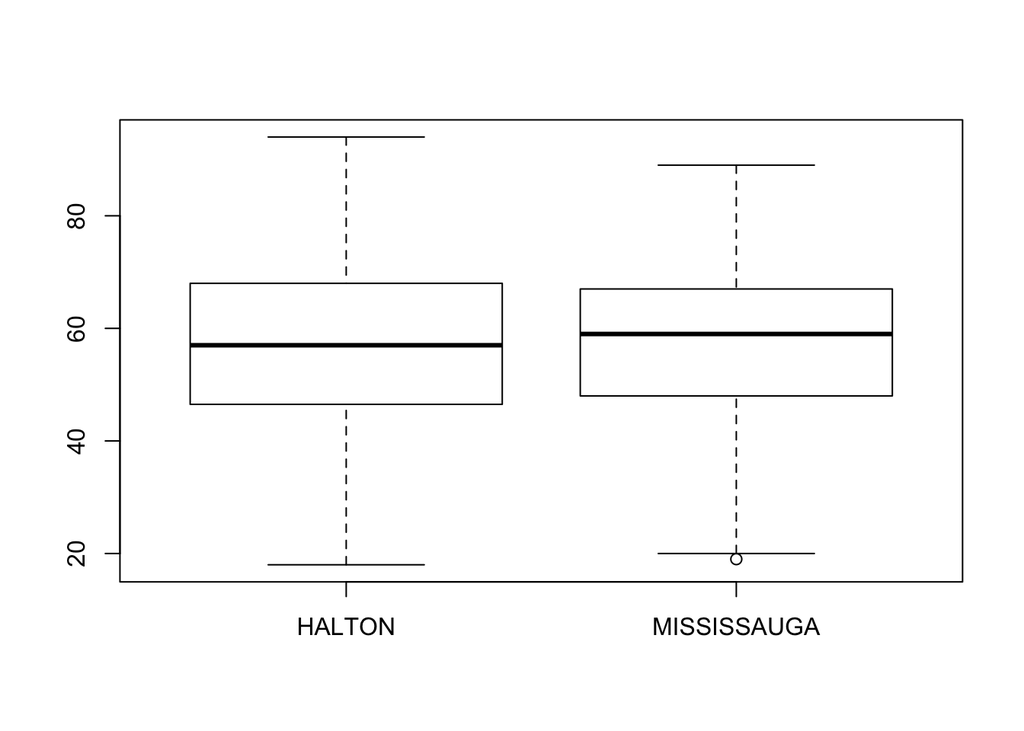

```r
boxplot(dataframe$age~dataframe$locationf)
```

outlier on Missussauga site no great difference in midean and spread for both sites

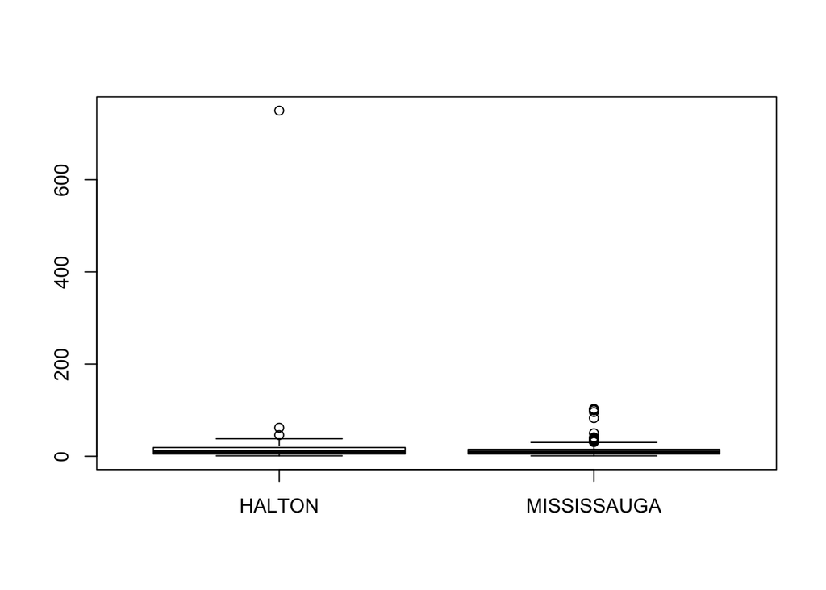

```r
boxplot(dataframe$distance~dataframe$locationf)
```

one outlier on the Halton site (a patient who travel over 750km to get to Halton- ture?) #2.numbers of patients with each social issue:

```r
socialissues <- table(dataframe$socialissue)
socialissues
```

```
##
##    social community    income   elderly     smoke     drugs   housing
##        38        11       100        29        40        14         3
##  mobility  language education      none
##        15        13         8       351
```

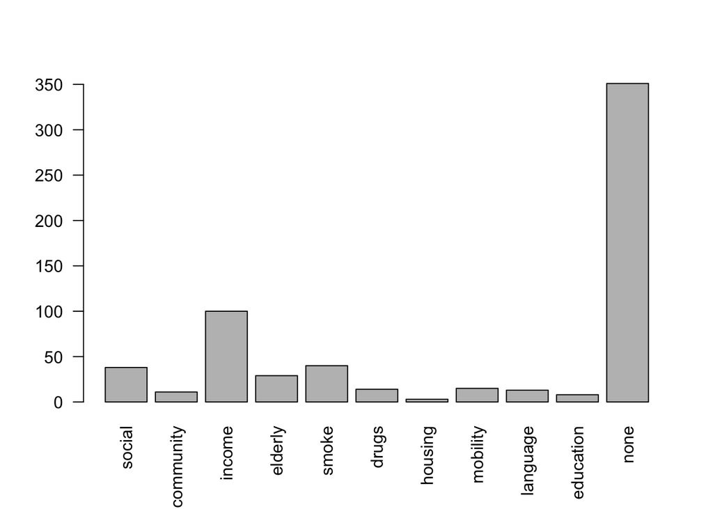

```r
plot(dataframe$socialissue,las=2)
```

compare to the impactful issues you mentioned, the following social issues appears to be more frequent: low income, social support, smoking, elderly #4.numbers of patients with each co-morbidity

```r
table(dataframe$Other)
```

```
##
## FALSE  TRUE
##   392   230
```

```r
table(dataframe$Eat)
```

```
##
## FALSE  TRUE
##   614     8
```

```r
#still working on producing a table that contains all the co-mobidity in a row with numbers counts for each co-mobidity
```

# 5.numbers of patients with mental health as co-morbidity:

```r
comomental <- table(dataframe$Mental)
comomental
```

```
##
## FALSE  TRUE
##   433   189
```

```r
which(dataframe$Mental)
```

```
##   [1]   2   7   9  10  11  26  27  31  32  38  40  41  46  52  56  69  78
##  [18]  80  85  87  94  96  97 104 110 112 122 123 124 127 128 134 135 150
##  [35] 159 161 166 167 169 170 174 176 178 179 181 190 191 195 197 198 199
##  [52] 200 204 207 208 210 213 215 227 230 232 241 248 249 251 253 257 259
##  [69] 261 265 266 270 272 273 274 277 279 284 285 291 292 293 295 302 303
##  [86] 316 317 320 324 325 327 329 330 332 340 342 344 345 352 354 356 357
## [103] 361 367 368 371 374 379 383 387 389 396 399 404 405 409 411 412 416
## [120] 419 420 421 424 425 426 430 432 433 437 446 452 456 457 463 467 468
## [137] 469 470 475 478 479 482 485 487 488 489 490 491 493 498 499 501 503
## [154] 506 515 517 521 524 525 530 531 533 536 538 542 547 550 555 556 558
## [171] 561 565 568 577 582 584 589 590 592 594 595 597 601 605 607 609 614
## [188] 618 622
```

still need to verify the the correct numebrs of patients have mental health as co-morbidity due to some repeated value issue numbers of patients with “other” as co-morbidity

```r
conmoother <- table(dataframe$Other)
conmoother
```

```
##
## FALSE  TRUE
##   392   230
```

```r
which(dataframe$Other)
```

```
##   [1]   1   2   4  12  14  18  22  23  24  25  36  40  41  43  44  45  48
##  [18]  49  53  59  60  61  62  64  65  66  69  70  74  75  78  80  89  92
##  [35]  94 104 112 114 119 120 134 139 144 146 151 156 159 162 165 167 168
##  [52] 170 172 175 177 178 179 181 186 192 193 196 197 198 199 200 201 202
##  [69] 203 205 206 208 209 210 211 212 214 217 219 220 224 228 229 230 232
##  [86] 241 247 249 250 254 257 258 263 270 271 273 274 275 276 278 279 283
## [103] 286 287 288 292 293 294 296 299 304 305 313 314 316 319 324 326 331
## [120] 341 342 343 346 347 349 350 352 354 355 360 362 364 366 368 371 373
## [137] 376 379 381 383 389 391 393 394 397 398 399 400 408 409 410 411 417
## [154] 421 422 423 426 427 428 429 430 431 432 440 445 448 453 454 457 458
## [171] 459 462 466 467 468 469 471 473 474 478 480 481 483 485 487 488 490
## [188] 492 494 496 501 502 509 521 522 524 525 530 533 538 541 542 545 546
## [205] 558 559 561 563 564 567 568 570 571 573 576 582 584 586 589 592 596
## [222] 602 604 607 608 610 612 613 617 619
```

```r
#335 vs. 230 --> very big difference
```

numbers of patients with “eat” as co-morbidity

```r
comoeat <- table(dataframe$Eat)
comoeat
```

```
##
## FALSE  TRUE
##   614     8
```

```r
#this is the same total numbers as per excel calculated

chronicother <- table(dataframe$COther)
chronicother
```

```
##
## FALSE  TRUE
##   593    29
```

```r
chronicamputation <- table(dataframe$Amput)
chronicamputation
```

```
##
## FALSE  TRUE
##   615     7
```

```r
#chronic numebrs are correct, no repeats
```

# 6. protions of F and M have metal health issue as co-morbidity

```r
comomental <- table(dataframe$Mental,dataframe$genderf)
comomental
```

```
##
##           M   F
##   FALSE 257 176
##   TRUE   87 102
```

```r
prop.table(comomental,margin=1)
```

```
##
##                 M         F
##   FALSE 0.5935335 0.4064665
##   TRUE  0.4603175 0.5396825
```

more females have mental health as co-morbidity #7.logistic data-mental vs. admit A1C

```r
logisticmentaladmitedA1C=glm(dataframe$Mental~dataframe$admit.A1C,family="binomial")
summary(logisticmentaladmitedA1C)
```

```
##
## Call:
## glm(formula = dataframe$Mental ~ dataframe$admit.A1C, family = "binomial")
##
## Deviance Residuals:
##     Min       1Q   Median       3Q      Max
## -0.9752  -0.8500  -0.8230   1.5110   1.6379
##
## Coefficients:
##                     Estimate Std. Error z value Pr(>|z|)
## (Intercept)         -1.22919    0.36300  -3.386 0.000709 ***
## dataframe$admit.A1C  0.03817    0.03475   1.098 0.272000
## ---
## Signif. codes:  0 '***' 0.001 '**' 0.01 '*' 0.05 '.' 0.1 ' ' 1
##
## (Dispersion parameter for binomial family taken to be 1)
##
##     Null deviance: 748.37  on 611  degrees of freedom
## Residual deviance: 747.17  on 610  degrees of freedom
##   (10 observations deleted due to missingness)
## AIC: 751.17
##
## Number of Fisher Scoring iterations: 4
```

not significant #8.logistic data-mental vs. discharged A1C

```r
logisticmentaldischargedA1C=glm(dataframe$Mental~dataframe$D.C.A1C,family="binomial")
summary(logisticmentaldischargedA1C)
```

```
##
## Call:
## glm(formula = dataframe$Mental ~ dataframe$D.C.A1C, family = "binomial")
##
## Deviance Residuals:
##     Min       1Q   Median       3Q      Max
## -1.0972  -0.8245  -0.7860   1.4651   1.7013
##
## Coefficients:
##                   Estimate Std. Error z value Pr(>|z|)
## (Intercept)       -1.71856    0.43811  -3.923 8.76e-05 ***
## dataframe$D.C.A1C  0.10179    0.05282   1.927    0.054 .
## ---
## Signif. codes:  0 '***' 0.001 '**' 0.01 '*' 0.05 '.' 0.1 ' ' 1
##
## (Dispersion parameter for binomial family taken to be 1)
##
##     Null deviance: 620.27  on 515  degrees of freedom
## Residual deviance: 616.61  on 514  degrees of freedom
##   (106 observations deleted due to missingness)
## AIC: 620.61
##
## Number of Fisher Scoring iterations: 4
```

almost significant slope is positive = meaning as discharged A1C level increase, the patients are more likely to have mental health issue as one of co-morbidity #9.the range of co-morbidities/complication?? #10.average # of co-morbidities #11.comparing admit and discharged clinical metrics:

```r
#A1C lelvel:
aggregate(cbind(admit.A1C,D.C.A1C)~genderf,data=dataframe,mean)
```

```
##   genderf admit.A1C  D.C.A1C
## 1       M  9.809375 7.859028
## 2       F 10.152889 8.087556
```

average Dischaged A1C level is lower for both male and female! Yes!

```r
#Lipids level(HDL cholesterol):
aggregate(cbind(admit.HDL.Cholesterol, D.C.HDL.Cholesterol)~genderf,data=dataframe,mean)
```

```
##   genderf admit.HDL.Cholesterol D.C.HDL.Cholesterol
## 1       M              1.227614            1.119773
## 2       F              1.254721            1.252132
```

```r
#lower discharged HDL cholesterol level in male, but same for female

#Lipids level(LDL cholesterol):
aggregate(cbind(admit.LDL.Cholesterol, D.C.LDL.Cholesterol)~genderf,data=dataframe,mean)
```

```
##   genderf admit.LDL.Cholesterol D.C.LDL.Cholesterol
## 1       M              2.128773            1.912112
## 2       F              2.435670            2.192474
```

```r
#both male and female have lower discharged LDL cholesterol levle = good thing!

#eGFR:
aggregate(cbind(admit.eGFR, D.C.eGFR)~genderf,data=dataframe,mean)
```

```
##   genderf admit.eGFR D.C.eGFR
## 1       M   78.00000 75.19940
## 2       F   78.92228 77.79793
```

```r
#both male and female have lower discharged eGFR levle

#Micro Albumin
aggregate(cbind(admit.Micro.Albumin, D.C.Micro.Albumin)~genderf,data=dataframe,mean)
```

```
##   genderf admit.Micro.Albumin D.C.Micro.Albumin
## 1       M            318.6737          453.2105
## 2       F            251.3692          191.0652
```

```r
#increase discharged microalbumin level for male, but decrease discharged microalbumin for female

#12.??Change in QoL index (which is DDS – Diabetes Distress Survey) = DDS Score Sub-scale B_Physician related distress (Discharge)


#13. Change in clinical metrics for subgroups: mental health patients
dataframe$Mental
```

```
##   [1] FALSE  TRUE FALSE FALSE FALSE FALSE  TRUE FALSE  TRUE  TRUE  TRUE
##  [12] FALSE FALSE FALSE FALSE FALSE FALSE FALSE FALSE FALSE FALSE FALSE
##  [23] FALSE FALSE FALSE  TRUE  TRUE FALSE FALSE FALSE  TRUE  TRUE FALSE
##  [34] FALSE FALSE FALSE FALSE  TRUE FALSE  TRUE  TRUE FALSE FALSE FALSE
##  [45] FALSE  TRUE FALSE FALSE FALSE FALSE FALSE  TRUE FALSE FALSE FALSE
##  [56]  TRUE FALSE FALSE FALSE FALSE FALSE FALSE FALSE FALSE FALSE FALSE
##  [67] FALSE FALSE  TRUE FALSE FALSE FALSE FALSE FALSE FALSE FALSE FALSE
##  [78]  TRUE FALSE  TRUE FALSE FALSE FALSE FALSE  TRUE FALSE  TRUE FALSE
##  [89] FALSE FALSE FALSE FALSE FALSE  TRUE FALSE  TRUE  TRUE FALSE FALSE
## [100] FALSE FALSE FALSE FALSE  TRUE FALSE FALSE FALSE FALSE FALSE  TRUE
## [111] FALSE  TRUE FALSE FALSE FALSE FALSE FALSE FALSE FALSE FALSE FALSE
## [122]  TRUE  TRUE  TRUE FALSE FALSE  TRUE  TRUE FALSE FALSE FALSE FALSE
## [133] FALSE  TRUE  TRUE FALSE FALSE FALSE FALSE FALSE FALSE FALSE FALSE
## [144] FALSE FALSE FALSE FALSE FALSE FALSE  TRUE FALSE FALSE FALSE FALSE
## [155] FALSE FALSE FALSE FALSE  TRUE FALSE  TRUE FALSE FALSE FALSE FALSE
```

[output cut: 42 more lines]

```r
#extract patients with "Ture" on mental health, then compare the admit and discharge clinical matrix among those patients

#14. Change in clinical metrics for subgroups: patients with wounds
dataframe$CWounds
```

```
##   [1] FALSE FALSE FALSE FALSE FALSE FALSE FALSE  TRUE FALSE FALSE FALSE
##  [12] FALSE FALSE FALSE FALSE FALSE FALSE FALSE FALSE FALSE FALSE FALSE
##  [23] FALSE FALSE FALSE FALSE FALSE FALSE FALSE FALSE FALSE FALSE FALSE
##  [34] FALSE FALSE FALSE FALSE FALSE FALSE FALSE FALSE FALSE FALSE FALSE
##  [45] FALSE FALSE FALSE FALSE FALSE FALSE FALSE FALSE FALSE FALSE FALSE
##  [56] FALSE FALSE FALSE FALSE FALSE FALSE FALSE FALSE FALSE FALSE FALSE
##  [67] FALSE FALSE FALSE FALSE FALSE FALSE FALSE FALSE FALSE FALSE FALSE
##  [78] FALSE FALSE FALSE FALSE FALSE FALSE FALSE FALSE FALSE FALSE FALSE
##  [89] FALSE FALSE FALSE FALSE FALSE FALSE FALSE FALSE FALSE FALSE FALSE
## [100] FALSE FALSE FALSE FALSE FALSE FALSE  TRUE FALSE FALSE FALSE FALSE
## [111] FALSE FALSE FALSE FALSE FALSE FALSE FALSE FALSE FALSE FALSE FALSE
## [122]  TRUE FALSE FALSE FALSE FALSE FALSE FALSE FALSE  TRUE FALSE FALSE
## [133] FALSE FALSE FALSE FALSE FALSE FALSE FALSE FALSE FALSE FALSE FALSE
## [144] FALSE FALSE FALSE FALSE FALSE FALSE FALSE FALSE FALSE FALSE FALSE
## [155] FALSE FALSE  TRUE FALSE FALSE FALSE FALSE FALSE  TRUE FALSE FALSE
```

[output cut: 42 more lines]

```r
#14. Change in clinical metrics for subgroups: frail elderly patients
#extract patients with age >70???
```